# Project on Credit card Fraud Detection

SWAPNIL SANJAY CHAVAN

10/17/2019

## Business Problem: Credit card fraud detection using supervise ML Model/Algorithm in R language

### Fraud Detection

#### Library used

```r
library(randomForest)
```

```r
library(e1071)
library(rpart)
library(rpart.plot)
library(caTools)
```

#### Read and Classify the Data

```r
card<-read.csv("creditcard.csv")

str(card)
```

#### Class Factor

```r
card$Class<-factor(card$Class)
```

#### Run code on both ends set any value I put 1

```r
set.seed(1)
```

#### Find Number of Rows

```r
nrow(card)
```

```
## [1] 284807
```

#### Divide entire Dataset into Training and Testing Datasets

T= Training Datasets(70% Data)

F= Testing Datasets(30% Data)

```r
split<-sample.split(card$Class,SplitRatio = 0.7)
train<-subset(card,split==T)
cv<-subset(card,split==F)
nrow(train)
nrow(cv)
```

#### Creat table and Find Fraudulant transaction

efficiency is greater than 99 percent

```r
table(cv$Class)
```

```
##
##     0     1
## 85295   148
```

```r
85265/(85265+148)
```

```
## [1] 0.9982672
```

#### Logistic regression:

Logistic regression because set transaction is in 0 and 1

Dependant variable= categorical variable / Dependant vaviable= Set of parameter

binomial= Dependant variable in 0 and 1

.= Consider all variable as independant variable except Class

Class= Dependant variable

glm=Logistic regression Model

```r
glm.model<-glm(Class~.,data=train,family = "binomial")
```

#### Predicting glm.Model

```r
glm.predict<-predict(glm.model,cv,type = "response")
glm.predict
nrow(cv)
```

#### Compare Class and Predicted glm model value to categorise fraudulant and Non-fraudulent transaction

if predicted value is greater than 0.5 it is fraudulent transaction

if predicted value is less than 0.5 it is non-fraudulent transaction

table produce gives confusion matrixa and accuracy is arount 99%

```r
table(cv$Class,glm.predict>0.5)
```

```
##
##     FALSE  TRUE
##   0 85279    16
##   1    69    79
```

#### Put and All predicated value in one file and Get working directory

save it as a “checkcredit.csv”

```r
cv$Class
glm.predict
cv$predict<-glm.predict
write.csv(cv,"checkcredit.csv")

getwd()
```

#### Tree Model developenent for better visualisation

For better visualiasation of the concept to the world

Basically How Algorithm Works

rpart= Classification and Regression Tree

minbucket= min number of observation at each node is 20

```r
tree.model<-rpart(Class~.,data = train,method = "class",minbucket=20)
```

#### Explanation of Tree

left side Yes

right side No

0= Non Fraudulant

1= fraudulant

if V17 value satisfies first condition it goes to left and check next condition.

if not it goes to right and check the next condition.

According to condition satisfaction we can easily understand which transaction is fraudulant and which is not

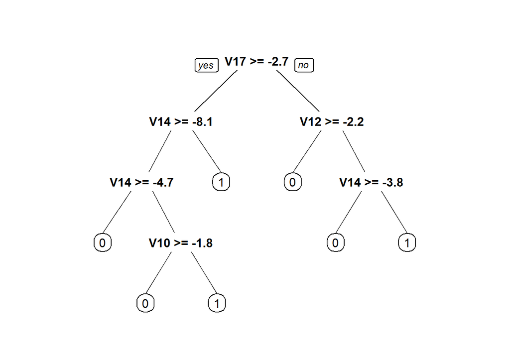

```r
prp(tree.model)
```

```r
tree.predict<-predict(tree.model,cv,type="class")
tree.predict
table(cv$Class,tree.predict)
```

## Finish the Program, Happy Coading…….

### Github: sscswapnil

### https://github.com/sscswapnil/Fraud-detection-with-R.git